# DevEcon_Project1

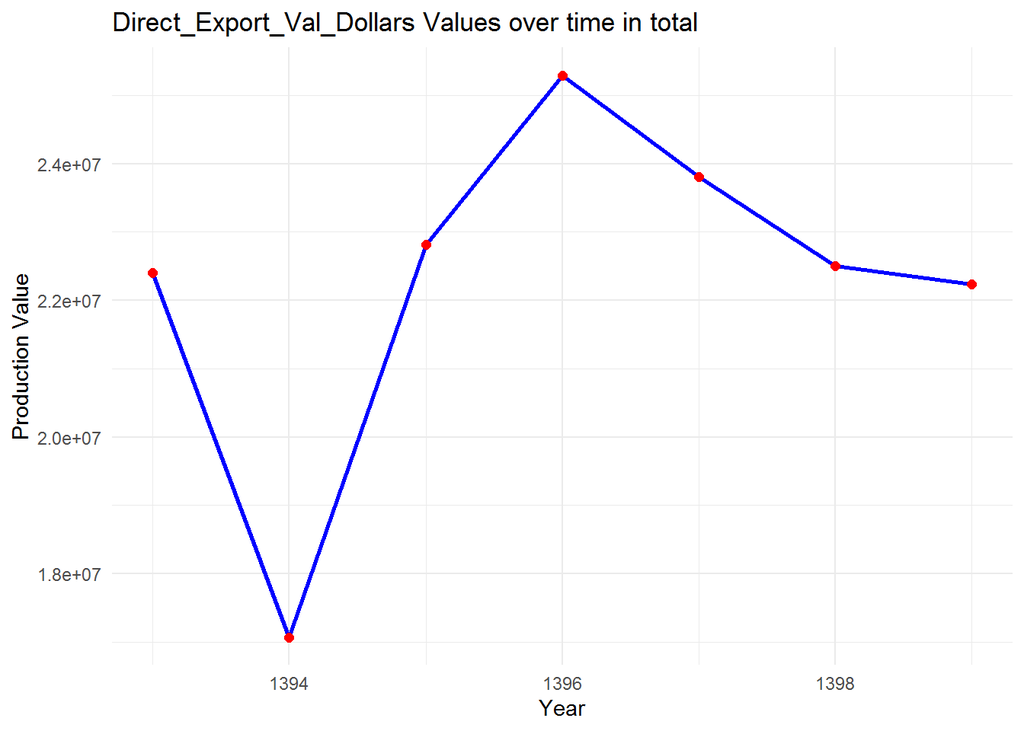

```r
ggsave("Direct_Export_Val_Dollars_Metals.pdf")


ggplot(total_data_2, aes(x = Year, y = Direct_Export_Val_Dollars)) +
  geom_line(color = "blue", size = 1) +
  geom_point(color = "red", size = 2) +
  labs(
    title = "Direct_Export_Val_Dollars Values over time in total",
    x = "Year",
    y = "Production Value"
  ) +
  theme_minimal()
```

```r
ggsave("Direct_Export_Val_Dollars_total.pdf")
```

In the earlier section, charts for dollar-denominated exports in the base metals sector and overall exports were presented. This time, the two charts are plotted side by side to highlight the parallel trends observed between 2014 and 2018. Considering the significant size of the base metals industry within Iran’s industrial landscape, approximately 15% of total dollar exports have been compared with the export trends of the base metals sector.

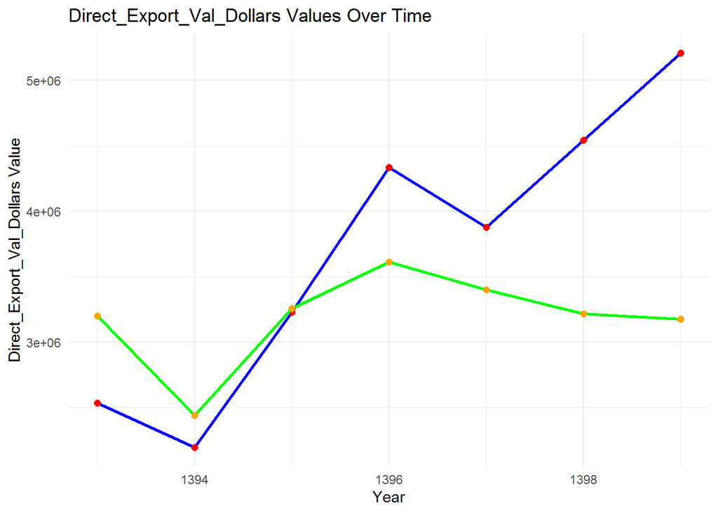

```r
ggplot() +
  geom_line(data = filtered_data_2, aes(x = Year, y = Direct_Export_Val_Dollars),
            color = "blue", size = 1) +
  geom_point(data = filtered_data_2, aes(x = Year, y = Direct_Export_Val_Dollars),
             color = "red", size = 2) +

  geom_line(data = total_data_2, aes(x = Year, y = (Direct_Export_Val_Dollars/7)),
            color = "green", size = 1) +
  geom_point(data = total_data_2, aes(x = Year, y = (Direct_Export_Val_Dollars/7)),
             color = "orange", size = 2) +

  labs(
    title = "Direct_Export_Val_Dollars Values Over Time",
    x = "Year",
    y = "Direct_Export_Val_Dollars Value"
  ) +
  theme_minimal()
```